# KeplerClassification - 2

```r
library(ggplot2)
library(dplyr)
data_path <- "data/"
data <- read.csv(paste0(data_path, "data_preprocessed.csv"))
```

Let’s start with some useful explorations of the data.

Let’s look at 4 different problematic events that the discover methods found in searching for the exoplanet.

```r
data %>%
  group_by(koi_fpflag_nt) %>%
  summarise(n())
```

| koi_fpflag_nt | n() |
| --- | --- |
| 0 | 7043 |
| 1 | 951 |

```r
data %>%
  group_by(koi_fpflag_co) %>%
  summarise(n())
```

| koi_fpflag_co | n() |
| --- | --- |
| 0 | 6250 |
| 1 | 1744 |

```r
data %>%
  group_by(koi_fpflag_ec) %>%
  summarise(n())
```

| koi_fpflag_ec | n() |
| --- | --- |
| 0 | 6913 |
| 1 | 1081 |

```r
data %>%
  group_by(koi_fpflag_ss) %>%
  summarise(n())
```

| koi_fpflag_ss | n() |
| --- | --- |
| 0 | 5861 |
| 1 | 2133 |

fpflag_ss seems to be the one most found. It describes a KOI that is observed to have a significant secondary event, transit shape, or out-of-eclipse variability, which indicates that the transit-like event is most likely caused by an eclipsing binary.

Analyzing the approximated temperature of the exoplanet (in Kelvin):

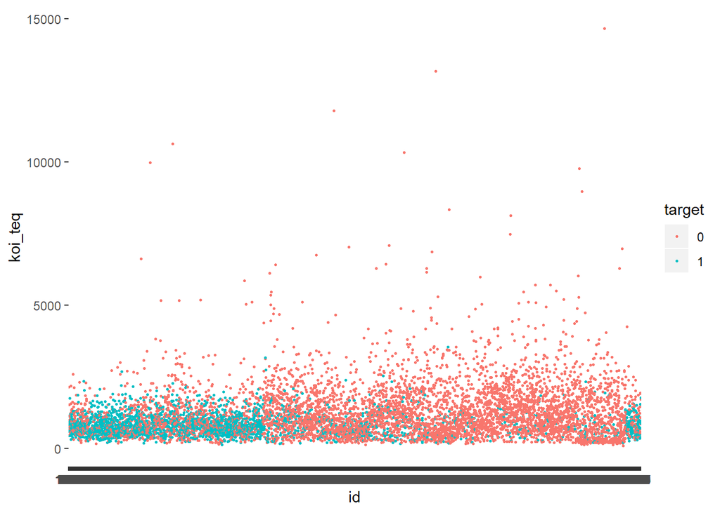

```r
data$target <- as.factor(data$target)
data$id <- rownames(data)
data %>% ggplot(aes(x = id, y = koi_teq, color = target)) +
  geom_point(size = 0.5)
```

```r
data %>%
  group_by(target) %>%
  summarise(mean(koi_teq), median(koi_teq))
```

| target | mean(koi_teq) | median(koi_teq) |
| --- | --- | --- |
| 0 | 1262.4917 | 1047 |
| 1 | 840.2679 | 782 |

There is not a clear pattern, even though from median and mean we can see that higher temperatures seem to refer to rejected exoplanet.

We are going to use the same method to analyze the stellar effective temperature (in Kelvin):

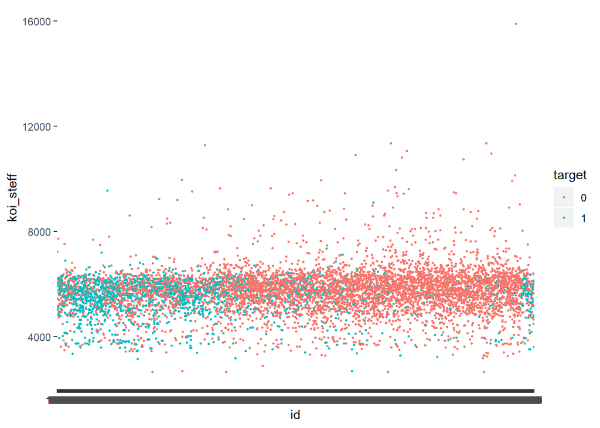

```r
data$id <- rownames(data)
data %>% ggplot(aes(x = id, y = koi_steff, color = target)) +
  geom_point(size = 0.5)
```

```r
data %>%
  group_by(target) %>%
  summarise(mean(koi_steff), median(koi_steff))
```

| target | mean(koi_steff) | median(koi_steff) |
| --- | --- | --- |
| 0 | 5776.557 | 5796 |
| 1 | 5478.179 | 5616 |

There is a slight difference between the judged exoplanet and not. This difference is mainly shown in the mean, symptom that it is influeced by outliers.

Let’s analyze the stars magnitude (brightness).

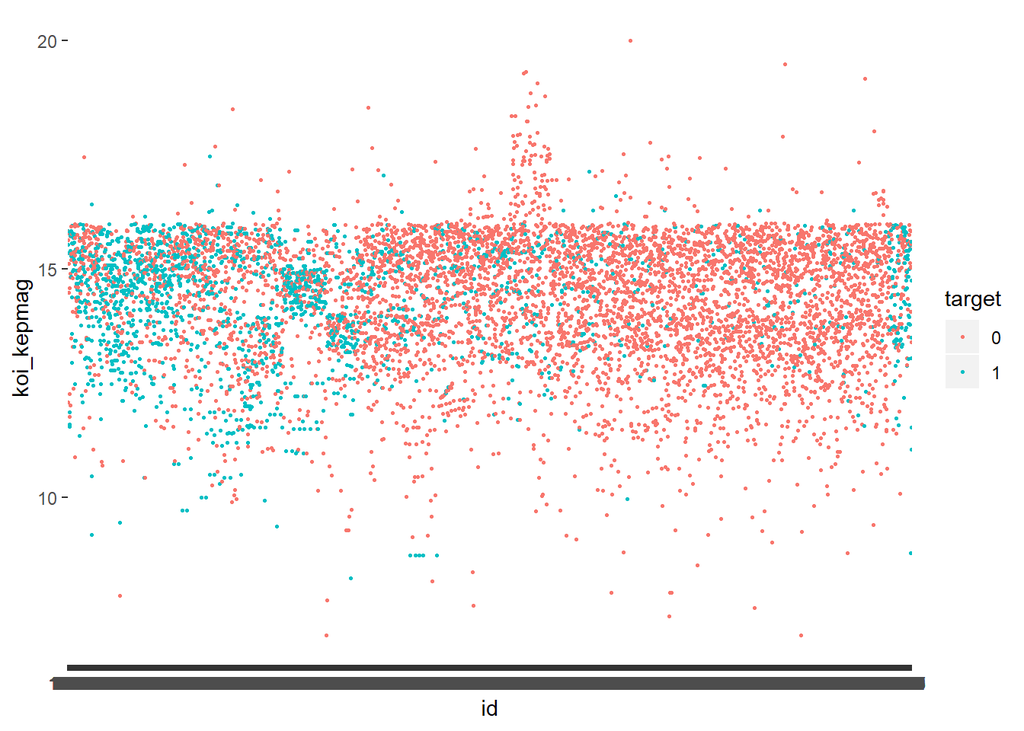

```r
data %>% ggplot(aes(x = id, y = koi_kepmag, color = target)) +
  geom_point(size = 0.5)
```

```r
data %>%
  group_by(target) %>%
  summarise(mean(koi_kepmag), median(koi_kepmag))
```

| target | mean(koi_kepmag) | median(koi_kepmag) |
| --- | --- | --- |
| 0 | 14.30893 | 14.572 |
| 1 | 14.34030 | 14.598 |

Graph and summary statistics do not show significant difference in stars magnitude between what we consider exoplanet and not.

Let’s do the same process for the planetary radius expressed as fraction of earth radii:

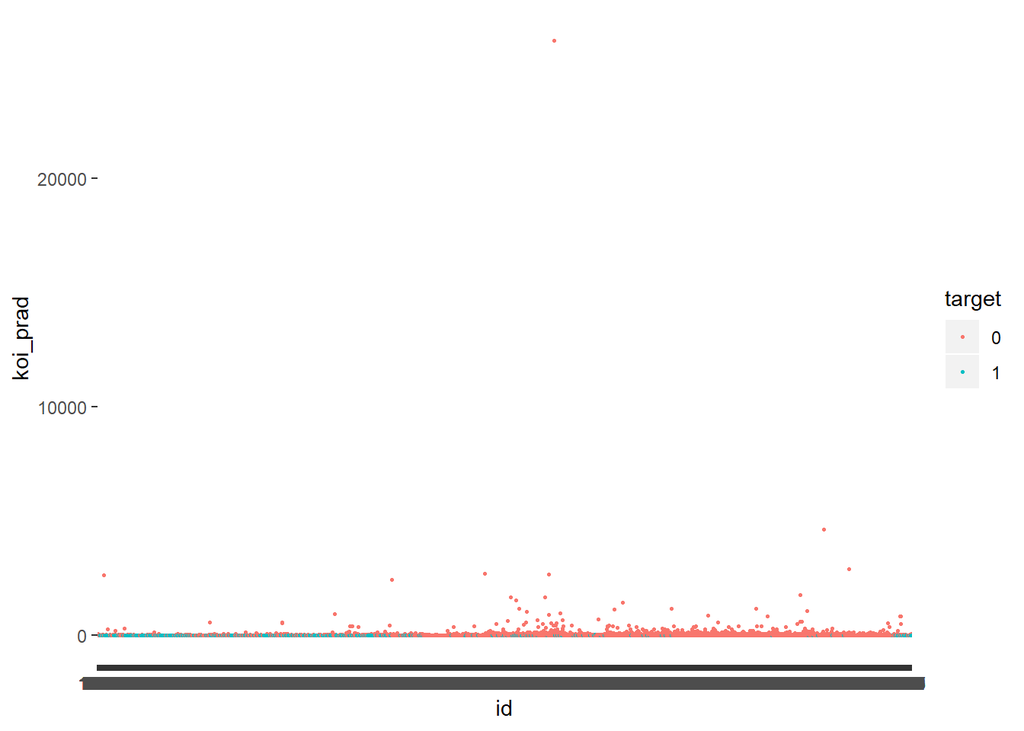

```r
data %>% ggplot(aes(x = id, y = koi_prad, color = target)) +
  geom_point(size = 0.5)
```

```r
data %>%
  group_by(target) %>%
  summarise(mean(koi_prad), median(koi_prad))
```

| target | mean(koi_prad) | median(koi_prad) |
| --- | --- | --- |
| 0 | 37.918509 | 3.09 |
| 1 | 2.871754 | 2.17 |

The presence of outliers leads to significant difference between exoplanet and not, especially in the mean.

Let’s visualize now the KOI position on the celestial sphere in the equatorial coordinate system:

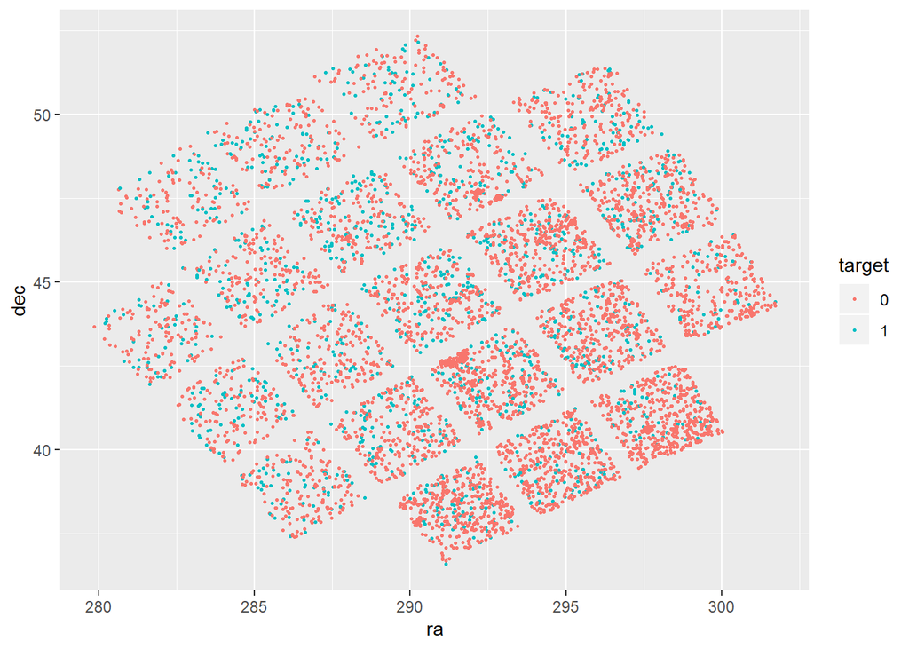

```r
data %>%
  ggplot(aes(x = ra, y = dec, color = target)) +
  geom_point(size = 0.5)
```

Finally, we can observe the target variable:

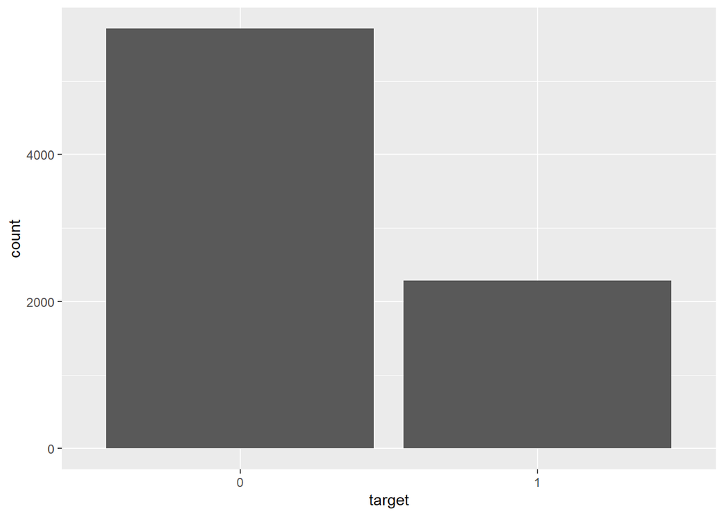

```r
data %>%
  ggplot(aes(x = target)) +
  geom_histogram(stat = "count")
```

```r
data %>%
  group_by(target) %>%
  summarise(n())
```

| target | n() |
| --- | --- |
| 0 | 5713 |
| 1 | 2281 |

As we can see from the histogram and the table above, the target variable is unbalanced: the class 1 is roughly the 30% of the total. This can lead to several issues that we can address with methods such as oversampling.